# Data Science of Everyday Music Listening: Project Beta (1)

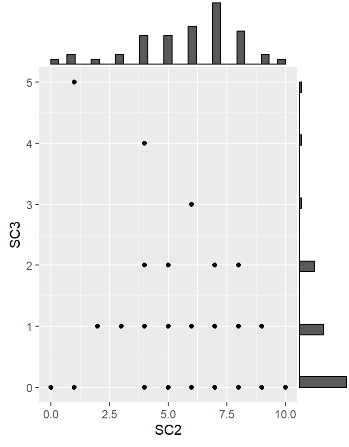

[figure not shown]

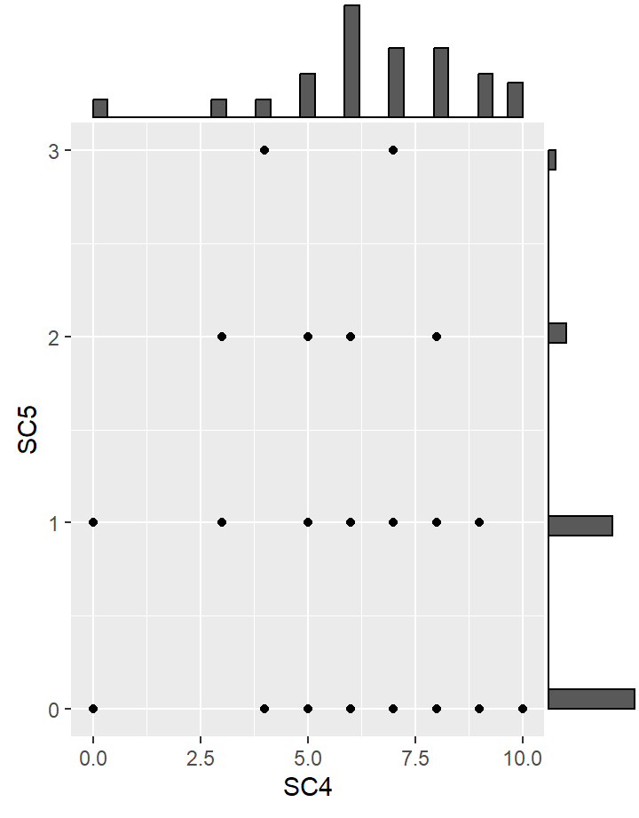

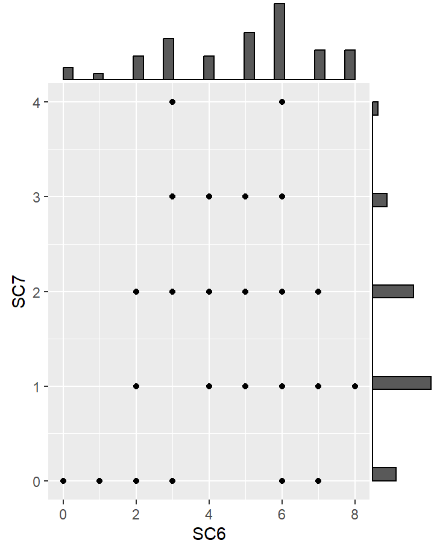

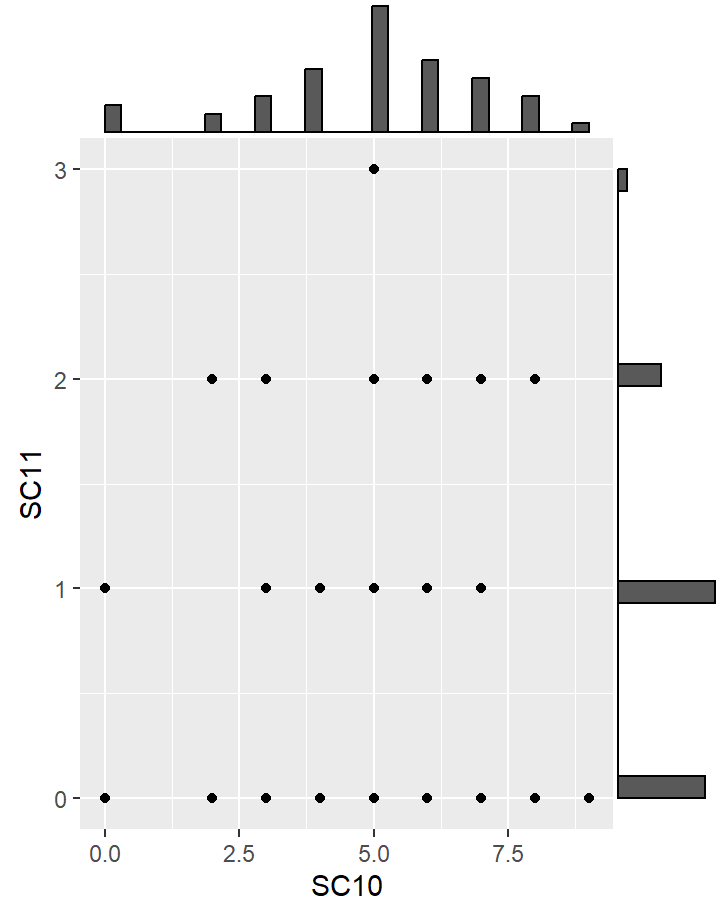

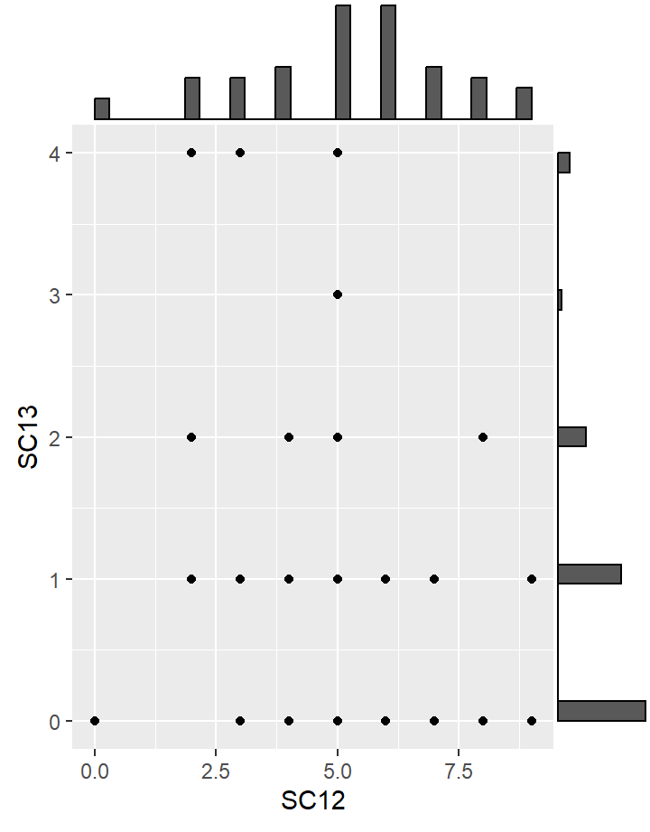

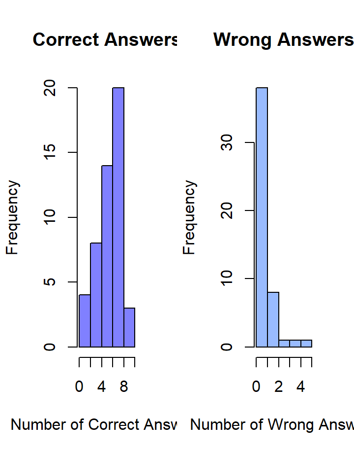

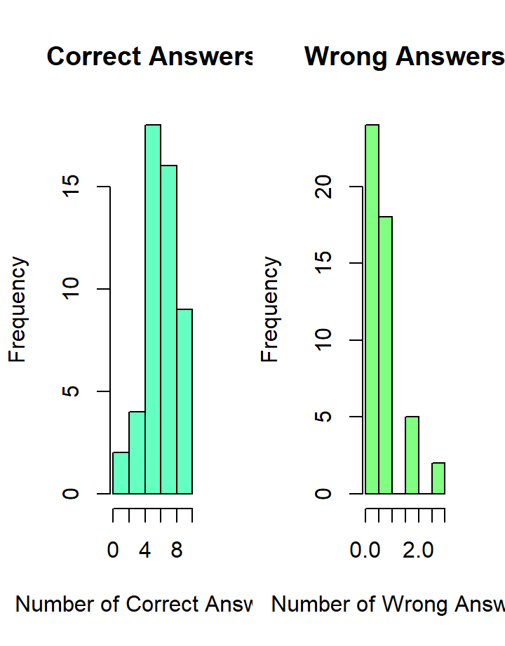

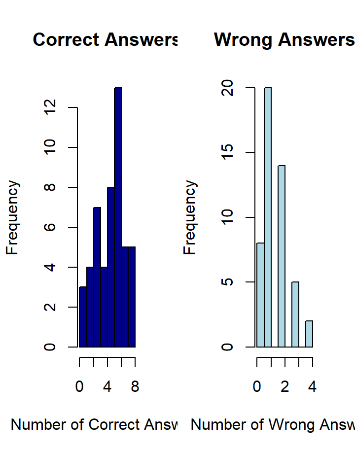

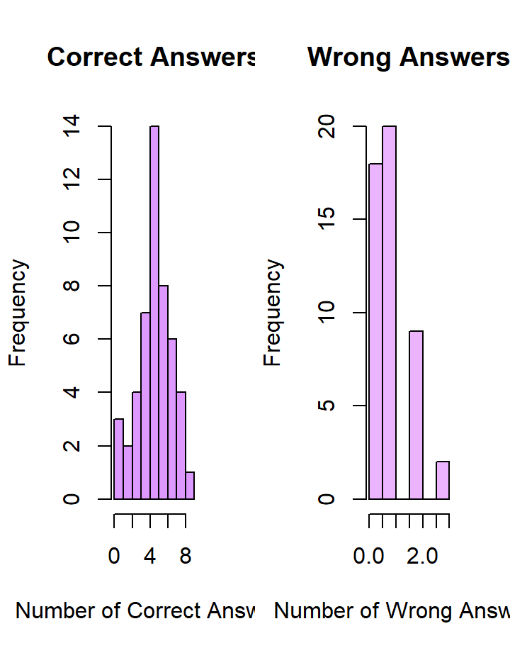

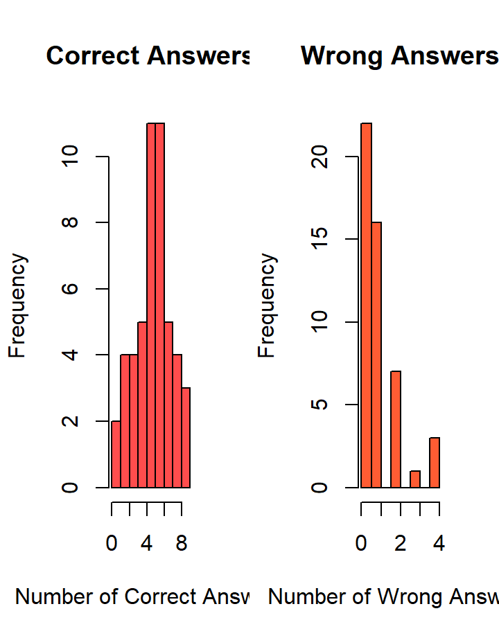

# Introduction

### Motivation

**Adel**

I often listen to music while studying and have always wondered whether I can utilize different genres and types of music to speed up the process of memorizing new information and help me study better. I’m curious about whether a catchy tune or a relaxing melody can actually make a difference in how we learn and recall information. Our study is all about finding out how the music we listen to can shape the way our brains work when we’re trying to remember and recall information. It’s a mix of my love for music and a natural curiosity about how it impacts our minds in daily life.

**Ana-Maria**

In elementary school, my teacher used to play us Bach and Mozart during different classes as math, art, or literature. She used to tell us that classical music can help us learn better and that other genres, like rock or pop, are not welcomed in our study routines. Growing up, I noticed that rock music went hand in hand with math, pop with programing and classical with reading and that other genres could help me have better performance while learning depending on my music preference in that certain moment. The fact that I could study well when listening to other genres, made me question my teacher’s belief. In this project, I have the opportunity to see if listening to classical music while studying is really beneficial and if there are other genres that can facilitate better results when it comes to memory stimulation in studying.

**Aron**

My motivation for conducting an experiment on how different music affects a person’s ability to recall information stems from my personal experience as a student. I have noticed a distinct difference in my studying habits when it comes to various subjects. Specifically, I find that I can focus well on mathematics and statistics when accompanied by music, as it seems to enhance my engagement with the material.

On the contrary, when delving into economic methodology, a more philosophical and abstract subject, I find that I prefer complete silence or the subtle background of beta waves. This discrepancy in my preferred study environments for different subjects has sparked my curiosity about the potential impact of music on cognitive functions, particularly memory and recall.

**Nienke**

Music is an integral part of my life. My father is a jazz musician and my mom plays the cello and works for the classical music radio. Naturally, from a young age I have been exposed to different genres of music and music theory. Because of this, I have started listening to music during almost every task imaginable, including studying. Background music has often made tasks easier to complete, but it has also interrupted my studying or my ability to memorize information. By doing this research I am hoping to find out whether studying results might be enhanced by music, and if so whether different genres could produce different results. Maybe after this research I can use music in a way that makes my studying process more efficient.

### Main Graph

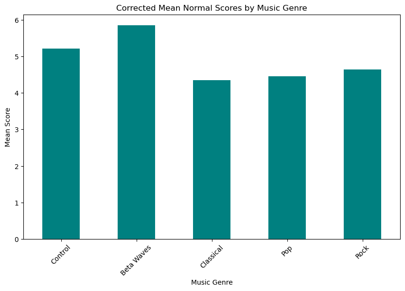

### Boxplot

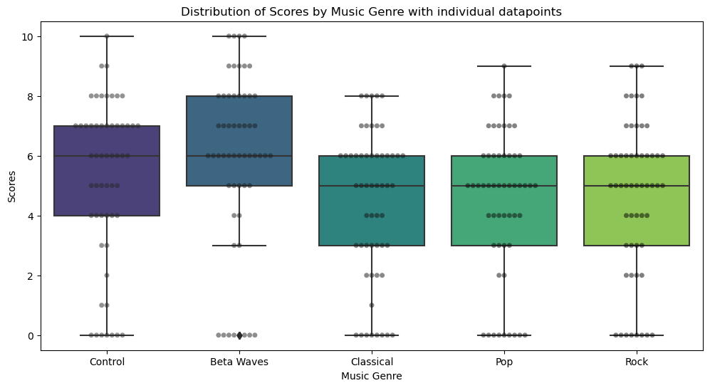

## Column {data-width = 10}

### Introduction

**Main Chart Interpretation**

# Methodology

### Genres

4

### Questions

15

### Videos

7

[figure not shown]

## Column {data-width = 10}

### Music 1

### Music 2

### Music 3

### Music 4

# Results

### Control

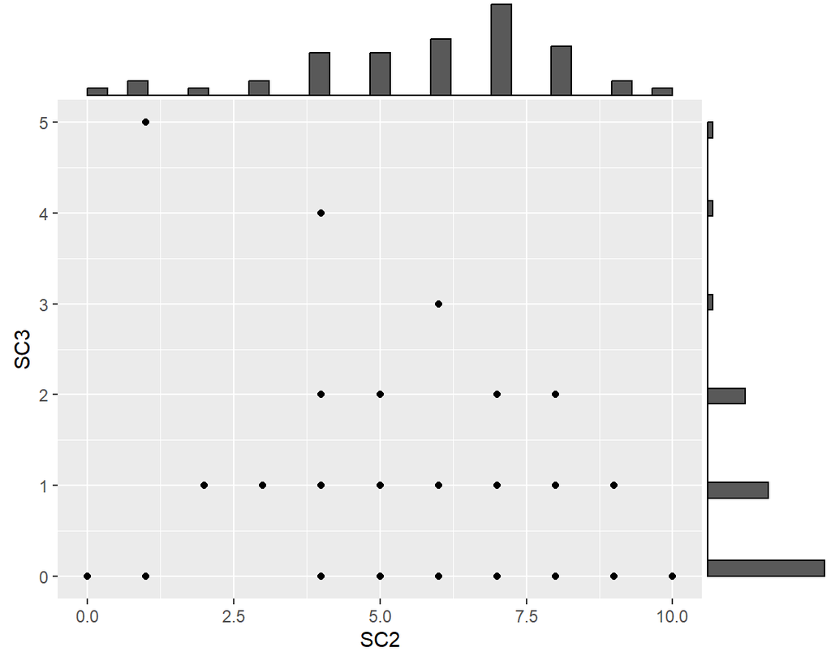

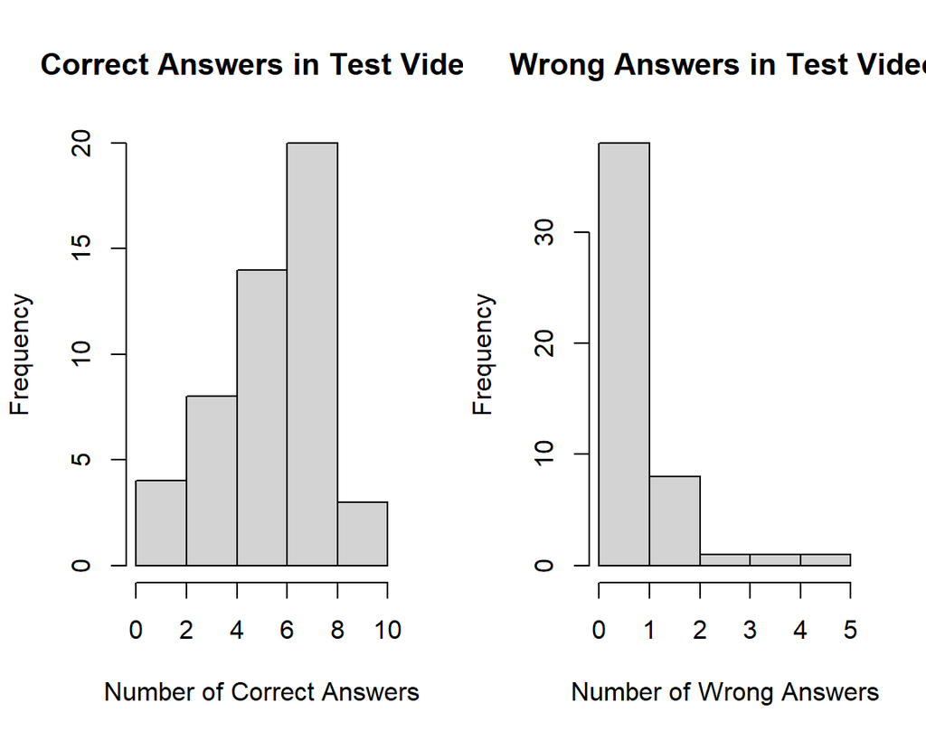

### Beta Waves

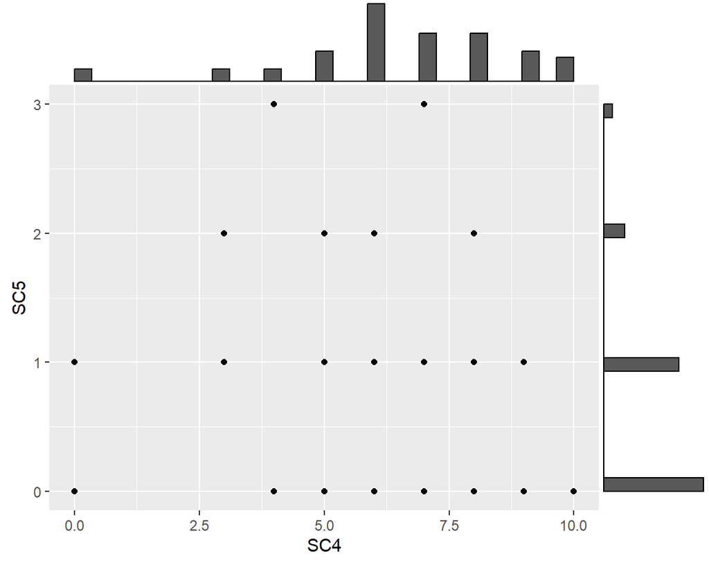

### Classical Music

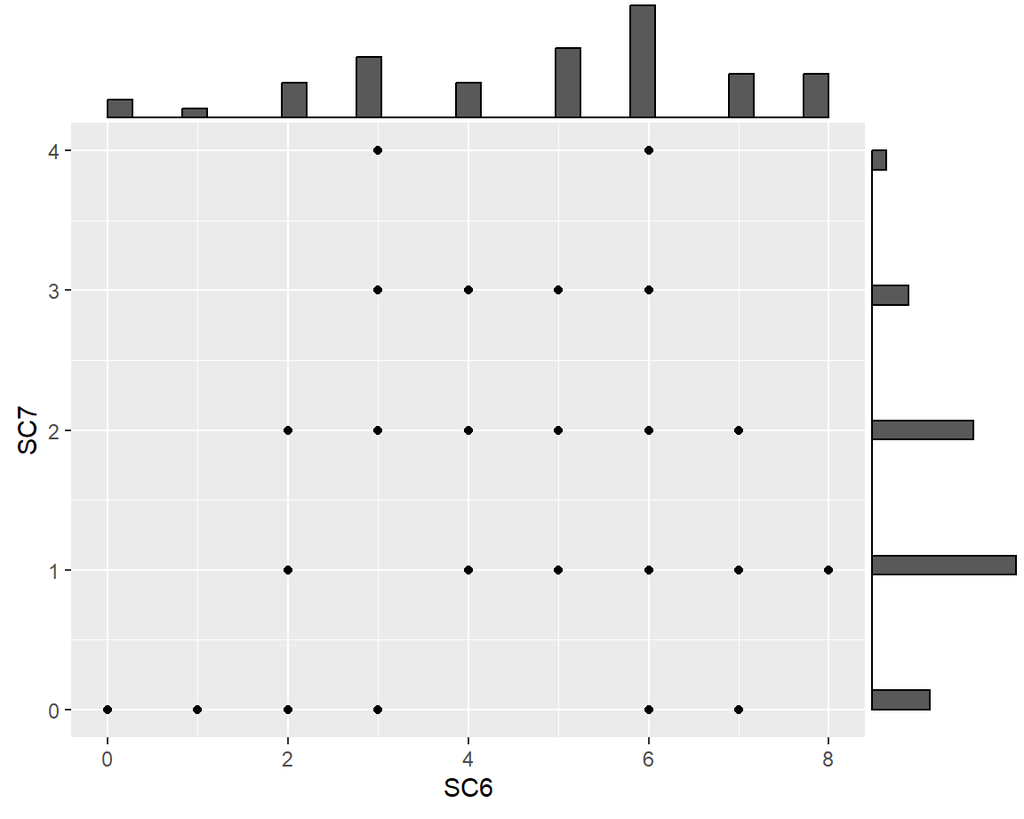

### Pop Music

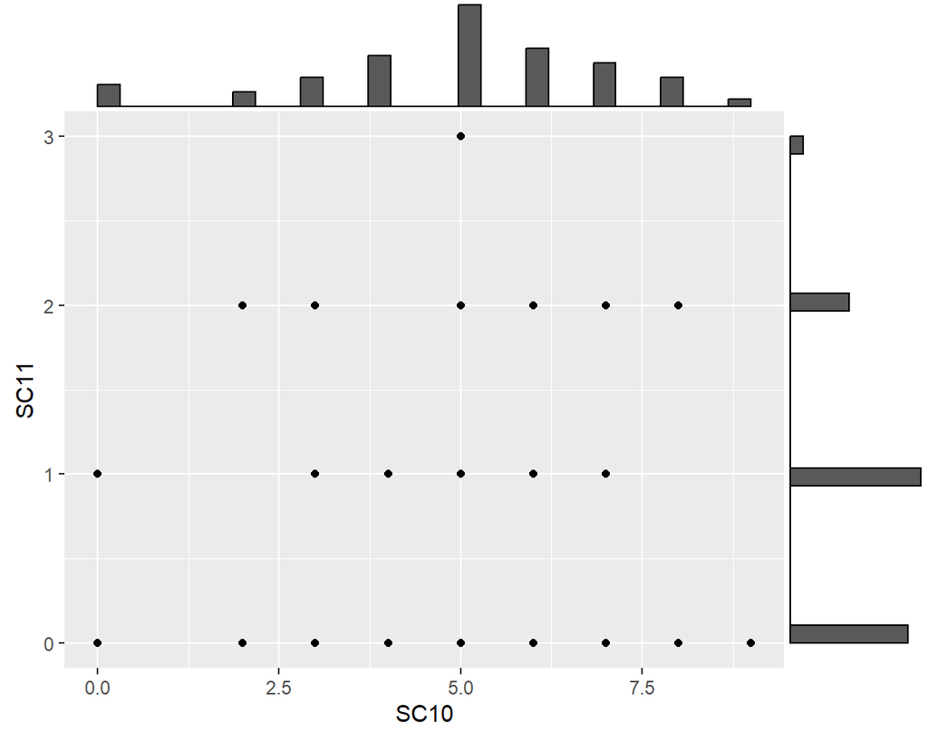

### Rock Music

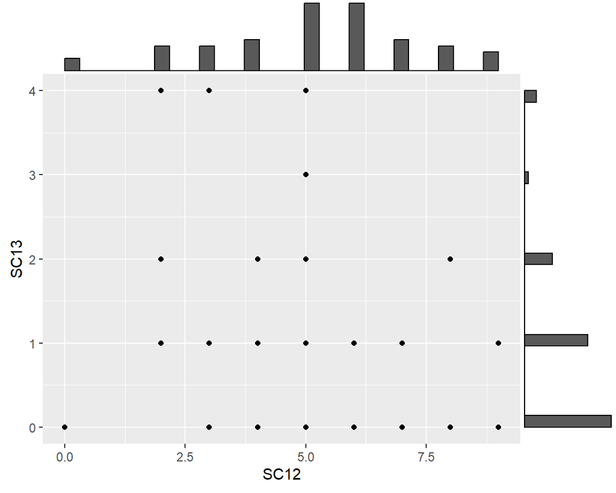

### Control

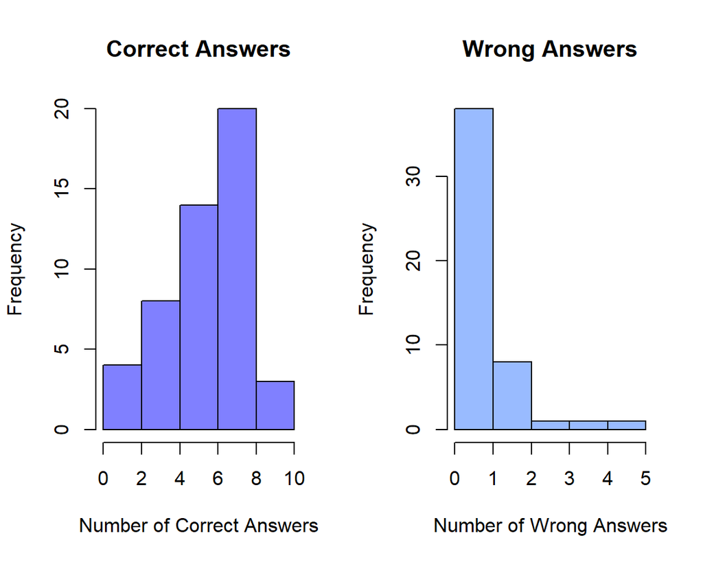

### Beta Waves

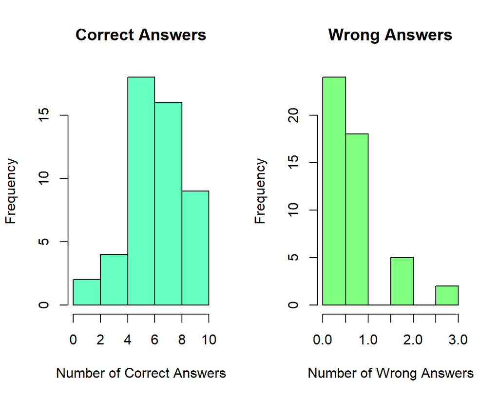

### Classical Music

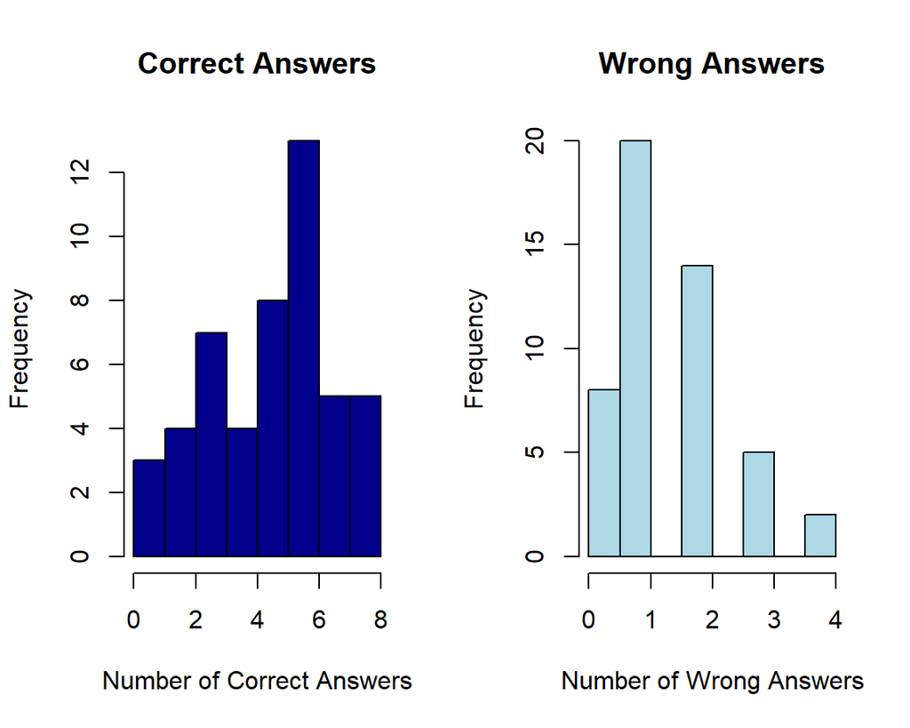

### Pop Music

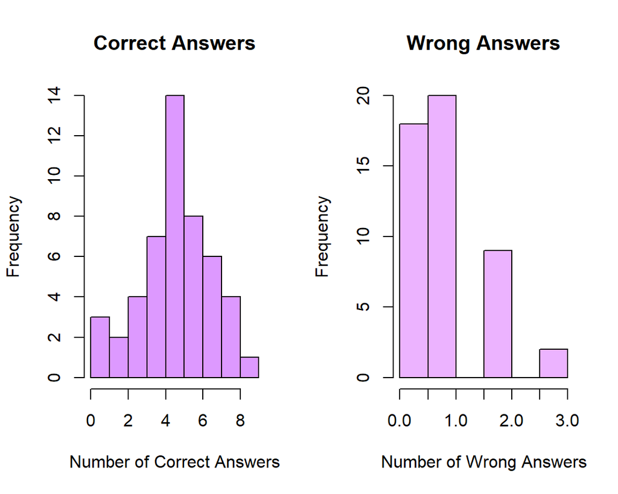

### Rock Music

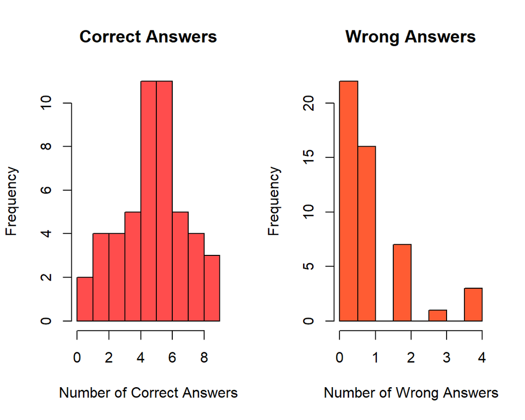

### Age

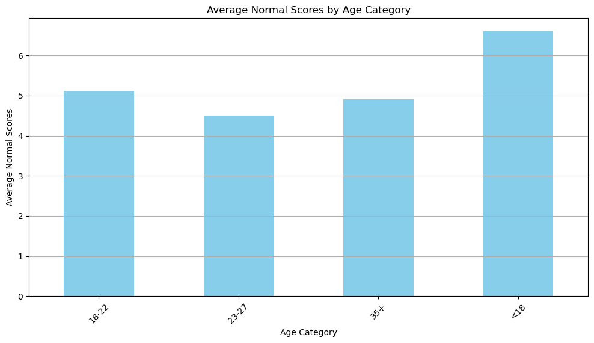

### Tasks

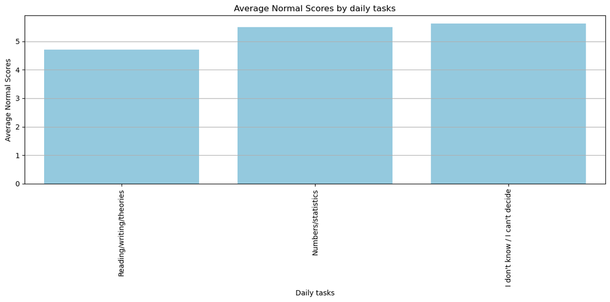

### Study

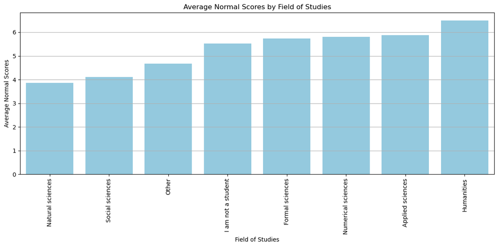

### Significance

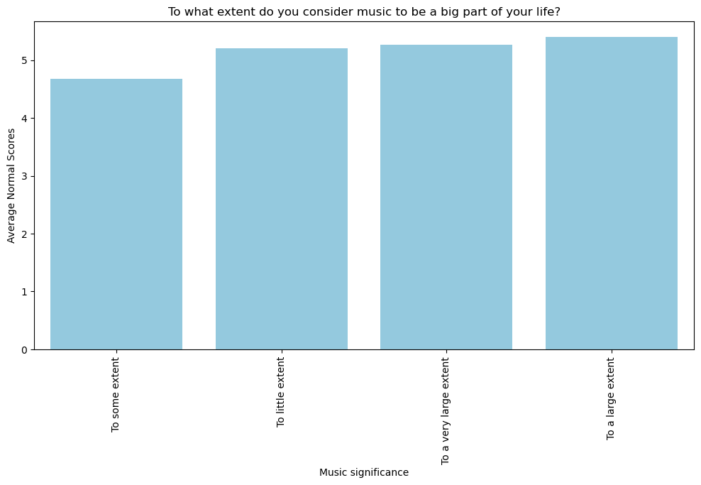

### Description

**Control**

**Beta Waves**

**Classical Music**

**Pop Music**

**Rock Music**

# Conclusion

### ANOVA

For Beta waves vs Control: The p-value is higher than 0.05, indicating no statistically significant difference.

For Classical vs Control and Pop vs Control: The p-values are lower than 0.05, suggesting statistically significant differences in scores when compared to the control group.

For Rock vs Control: The p-value is close to 0.05, indicating a trend towards significance, but it’s not conclusively significant at the standard 0.05 level.

Therefore, based on this analysis, the genres “Classical” and “Pop” show statistically significant differences in scores compared to the control group, whereas “Beta waves” and “Rock” do not demonstrate statistically significant differences at the conventional 0.05 level.

For Control vs Beta waves: The p-value is higher than 0.05, suggesting no statistically significant difference.

For Classical vs Beta waves, Pop vs Beta waves, and Rock vs Beta waves: The p-values are lower than 0.05, indicating statistically significant differences in scores when compared to the Beta waves group.

Thus, in this analysis, the genres “Classical”, “Pop”, and “Rock” show statistically significant differences in scores compared to the Beta waves group.

### Table Control

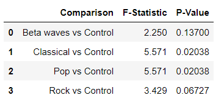

### Table Beta Waves

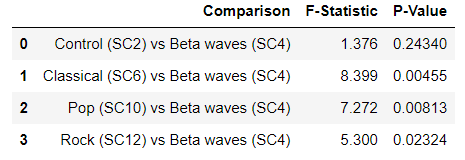

### Conclusion & Discussion

The results from our experiment show that overall the respondents were able to memorize the most numbers while listening to Beta Waves. The second best performance was during the control video with no music. These results are both close to each other and show that whether one listens to beta waves or no music does not make a significant difference when it comes to the ability to recall or memorize strings of numbers.

Our initial hypothesis was that respondents would recall most numbers while listening to no music, and recall a little bit less while listening to beta waves. In other words, we thought that a background noise would disrupt the ability to retain information. We did believe that music with melody and lyrics were going to cause a worse performance than music with no melody and lyrics. Thus, the hypothesis that respondents would do better while listening to no music than while listening to beta waves was false. However, it was correct that respondents would perform better while listening to no music and beta waves, than rock, pop or classical music.

### Limitation

In the classical music video two numbers were unintentionally repeated twice which could confuse participant and impact their scores for this exercise.

The questionnaire was quite long so some people could have lost focus towards the end.

In one of the videos there was a pattern that revealed itself after a couple of videos. Several numbers were paired up (5,6,8,9 etc.). This could have caused respondents to perform better during this video.

As the videos had the same structure, the participants could make strategies like keeping in mind lists of prime numbers’ multiples, in order to remember more numbers in the following videos. This fact could reduce the importance of the background music and focus more on the performance of the strategy.